# Neighbourhood of Th (CD14 negative) vs. ThCD14 positive

Sorin: Proportion analysis of Neighbourhoods

Ilariya Tarasova

March 27, 2025

# 1 Preparation

## 1.1 Loading data

```r
> cell_info_sorin <- readRDS("../../data/Sorin_cell_info.rds")
> distToThCD14pos <- readRDS("../../data/Sorin_distToThCD14pos.rds") #fresh file
> distToThCD14neg <- readRDS("../../data/Sorin_distToTh.rds")
> updCellType <- readRDS("../../data/updatedCellTypes_Sorin.rds")
> sorin_immune_subgr <- readRDS("../../data/Sorin_LUAD_immune_subgroups.rds")
```

## 1.2 Incorporating distance data

Distance data was calculated using *minDistToCells()* function from `imcRtools` package. https://bodenmillergroup.github.io/imcRtools/articles/imcRtools.html#minimal-distances-to-cells-of-interest Basicaly, it’s a Minimal distances to cells of interest (CD14+ or CD14- T cell)

```r
> cell_info_sorin$updCellType <- updCellType
> cell_info_sorin$distToThCD14pos <- distToThCD14pos
> cell_info_sorin$distToThCD14neg <- distToThCD14neg
>
> cell_info_sorin$immuneSubgroups <- sorin_immune_subgr$cluster[match(cell_info_sorin$Patient, sorin_immune_subgr$patient)]
> cell_info_sorin$immuneSubgroups <- as.character(cell_info_sorin$immuneSubgroups)
>
> status <- "in & out tumour"
> cell_info_sorin <- as.data.frame(cell_info_sorin#[cell_info_sorin$InTumour,]
+                                 )
> # Filtering out patients with low number of ThCD14+ cells
> filtered_df <- cell_info_sorin %>%
+     group_by(Patient) %>%
+     summarise(ThCD14posCount = sum(updCellType == "ThCD14+")) %>%
+     filter(ThCD14posCount >= 5) %>%
+     left_join(cell_info_sorin, by = "Patient")
> length(unique(filtered_df$Patient)) # how many patients have at least 10 ThCD14+ cells
```

```
[1] 397
```

```r
> cell_info_filt <- filtered_df[,c("Patient", "updCellType", "CellType_h2",
+                                     "distToThCD14neg",  "distToThCD14pos",
+                                  "immuneSubgroups")]
```

# 2 The non-double counting approach

Here I took all cells from one image that are within the radius 50 from any CD14+ or CD14- Th cell (separatelu for +/-). And I calculated percentages based on that, so no double counting of cells.

## 2.1 Data preparation

Let’s first filter out all cells that are not in the neighbourhood (of a particular radius) for both cell types of interest (Th and ThCD14+). After that, we are joining both filtered data sets.

```r
> radius <- 50
>
> cell_info_filt$cell_id <- paste0(cell_info_filt$Patient, "_", rownames(cell_info_filt))
> columns_of_interest <- c("Patient", "updCellType", "immuneSubgroups", "CellType_h2", "cell_id")
>
> prep_data <- cell_info_filt %>% filter(., distToThCD14neg <= radius)
> prep_data_neg <- prep_data[,columns_of_interest]
>
> prep_data <- cell_info_filt %>% filter(., distToThCD14pos <= radius)
> prep_data_pos <- prep_data[,columns_of_interest]
>
> prep_data_neg$group <- "neg"
> prep_data_pos$group <- "pos"
>
> for_test <- rbind(prep_data_neg, prep_data_pos)
```

## 2.2 Plot overlap

Lat’s look how much both neighbourhoods overlap (overall, and also split by immune subgroups)

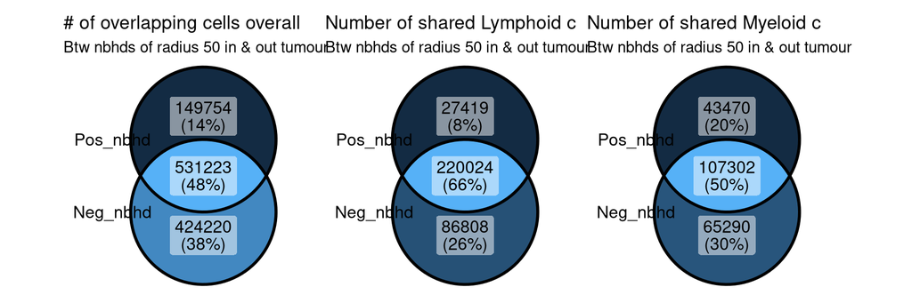

```r
> p1 <- ggVennDiagram(list(prep_data_neg$cell_id, prep_data_pos$cell_id),
+               category.names = c("Neg_nbhd", "Pos_nbhd"),)+
+   labs(title = "# of overlapping cells overall",
+        subtitle = paste0("Btw nbhds of radius ", radius, " ", status)) +
+   scale_x_continuous(expand = expansion(mult = .3))+theme(legend.position = "none")
>
> p2 <- ggVennDiagram(list(prep_data_neg$cell_id[prep_data_neg$CellType_h2 == "Lymphoid cell"],
+                    prep_data_pos$cell_id[prep_data_pos$CellType_h2 == "Lymphoid cell"]),
+               category.names = c("Neg_nbhd", "Pos_nbhd"),)+
+   labs(title = "Number of shared Lymphoid c",
+        subtitle = paste0("Btw nbhds of radius ", radius, " ", status)) +
+   scale_x_continuous(expand = expansion(mult = .3))+
+   theme(legend.position = "none")
>
> p3 <- ggVennDiagram(list(prep_data_neg$cell_id[prep_data_neg$CellType_h2 == "Myeloid cell"],
+                    prep_data_pos$cell_id[prep_data_pos$CellType_h2 == "Myeloid cell"]),
+               category.names = c("Neg_nbhd", "Pos_nbhd"),)+
+   labs(title = "Number of shared Myeloid c",
+        subtitle = paste0("Btw nbhds of radius ", radius, " ", status)) +
+   scale_x_continuous(expand = expansion(mult = .3))+theme(legend.position = "none")
>
> p1 + p2 + p3
```

We can see that overlap is significant, but not overwhelmingly.

# 3 Propeller

Next we will test difference in proportions of cell types in these neighbourhoods using propeller from [`speckle` package](https://bioconductor.org/packages/devel/bioc/vignettes/speckle/inst/doc/speckle.html).

## 3.1 Function to test

Plot results from `propeller`

```r
> plot_test_results <- function(res, plot_title, radius){
+     par(mfrow = c(1,3))
+   barplot(res$P.Value, names = rownames(res),
+           main = paste0("P.Val, ", plot_title),
+           sub = paste0("r ", radius),
+           las=2)
+   abline(h = 0.05, col = "red")
+
+   barplot(res$FDR, names = rownames(res),
+           main = paste0("FDR, ", plot_title),
+           sub = paste0("r ", radius),
+           las=2)
+   abline(h = 0.05, col = "red")
+
+   signif_res <- res[res$FDR < 0.05,]
+   #par(mfrow = c(1,1))
+   barplot(signif_res$Tstatistic, names = rownames(signif_res),
+           main = paste0("Signif, Tstat,
+                         neg-pos, ",plot_title),
+           sub = paste0("r ", radius),
+           las=2)
+ }
>
> plot_col_test_res <- function(res, plot_title, col_vect){
+   signif_res <- res[res$FDR < 0.05,]
+   signif_res <- signif_res[-which(rownames(signif_res) %in% c("Th", "ThCD14+")),]
+   small_col_vect <- col_vect[rownames(signif_res)]
+   par(mar = c(6,4,4,2))
+   barplot(signif_res$Tstatistic, names = rownames(signif_res),
+           main = paste0("Signif,
+                         Tstat, neg-pos, ",plot_title),
+           col = col_vect[rownames(signif_res)],
+           las=2)
+ }
```

This function uses `getTransformedProps` function to convert cell numbers in proportions and performs *logit* transformation. Design matrix includes *group* (neg or pos) factor and factor for *immune subgroups* (L, LM, M), as we know of the different % of lymphoid and myeloid cells in these groups of patients and we are not interested in the variability of those.

Then `propeller.ttest` function called to perform t-tests between two groups (neg - pos).

```r
> test_with_propeller <- function(for_test_LM, cluster, plot_title){
+   tr_prop <- getTransformedProps(sample = paste0(for_test_LM$Patient, "_",
+                                                  for_test_LM$group, "_",
+                                                  for_test_LM$immuneSubgroups),
+                    clusters = for_test_LM[[cluster]],
+                    transform = "logit")
+   split_name <- strsplit2(colnames(tr_prop$Counts), "_")
+   group <- split_name[,3]
+   patient <- split_name[,2]
+   immuneSubgr <- split_name[,4]
+   design <- model.matrix(~ 0 + group + immuneSubgr)
+   mycontr <- makeContrasts(groupneg-grouppos, levels=design)
+   res <- propeller.ttest(prop.list=tr_prop, design=design,
+                          contrasts = mycontr,
+                          robust=TRUE, trend=FALSE, sort=TRUE)
+
+   plot_test_results(res, plot_title, radius)
+   return(res)
+ }
```

Function for L immune subgroup. The difference with the previous function is that instead of immuneSubgroup factor I included *patient* as a factor to get the information on the pairings of data rows.

```r
> test_L_imm_subgr_with_propeller <- function(for_test_LM, cluster, plot_title){
+     tr_prop <- getTransformedProps(sample = paste0(for_test_LM$Patient, "_",
+                                                  for_test_LM$group),
+                    clusters = for_test_LM[[cluster]],
+                    transform = "logit")
+   split_name <- strsplit2(colnames(tr_prop$Counts), "_")
+   group <- split_name[,3]
+   patient <- split_name[,2]
+   design <- model.matrix(~ 0 + group + patient)
+   mycontr <- makeContrasts(groupneg-grouppos, levels=design)
+   res <- propeller.ttest(prop.list=tr_prop, design=design,
+                          contrasts = mycontr,
+                          robust=TRUE, trend=FALSE, sort=TRUE)
+
+   plot_test_results(res, plot_title, radius)
+   return(res)
+ }
```

## 3.2 Function to plot proportions

```r
> CellType_h2_colours <- c("Cancer" = "#525252",
+    "Endothelial cell" = "#990000",
+    "Lymphoid cell" = "#fb6a4a",
+    "Myeloid cell" = "#43a2ca",
+    "Other" = "#bdbdbd")
> cd14pos_L_and_M_colors <- c(
+   "Tc" = "#e7298a",
+   "Th" = "#d57cd4",
+   "TcCD14+" = "#f595d2",
+   "ThCD14+" = "#f4cff3",
+   "Treg" = "#fd693a",
+   "T other" = "#ce1256",
+   "B cell" = "red",
+   "NK cell" = "#8c6bb1",
+   "NK_CD14+" = "#88419d",
+   "Alt MAC" = "#5886a5",
+   "Cl MAC" = "#00cee6",
+   "Cl Mo" = "#00cbc9",
+   "Int Mo" = "#02a19e",
+   "Non-Cl Mo" = "#017976",
+   "Mast cell" = "greenyellow",
+   "Neutrophils" = "seagreen1",
+   "DCs cell" = "royalblue1"
+ )
>
> plot_prop <- function(tets_results, sub_title){
+   number_of_cell_types <- as.character(nrow(tets_results))
+   plot_colours <- switch (number_of_cell_types,
+                           "17" = cd14pos_L_and_M_colors,
+                           "9" = cd14pos_L_and_M_colors[1:9],
+                           "8" = cd14pos_L_and_M_colors[10:17],
+                          "5" = CellType_h2_colours)
+   test <- tets_results[,1:2]
+   colnames(test) <- gsub("PropMean.group", "", colnames(test))
+   test$cellTypes <- rownames(test)
+   test2 <- pivot_longer(test, cols = !cellTypes,
+                         names_to = "cond",
+                         values_to = "prop")
+   test2$cellTypes <- factor(test2$cellTypes, levels = names(plot_colours))
+   ggplot(test2, aes(x = cond,y = prop, fill = cellTypes)) +
+     geom_bar(position="fill", stat="identity")+
+    scale_fill_manual(values=plot_colours)+
+                 labs(title = paste0("Cell types within radius ", radius),
+                  subtitle = sub_title,
+                  y = "Proportion mean from Propeller",
+                  x = "Neighbourhood of Th...")+
+         theme_bw()
+ }
```

## 3.3 Broad cell types

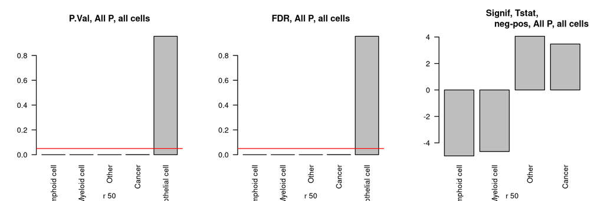

```r
> ttl <- "All P, all cells"
> res <- test_with_propeller(for_test, "CellType_h2", ttl)
```

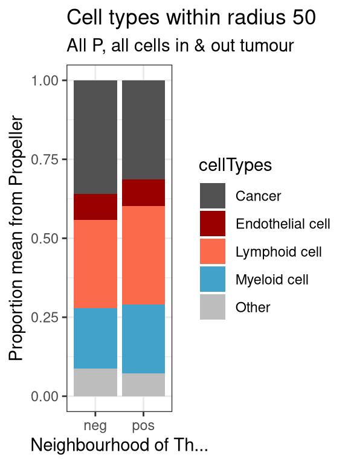

```r
> plot_prop(res, paste(ttl, status))
```

## 3.4 Lymphoid and Myeloid together

### 3.4.1 All patients

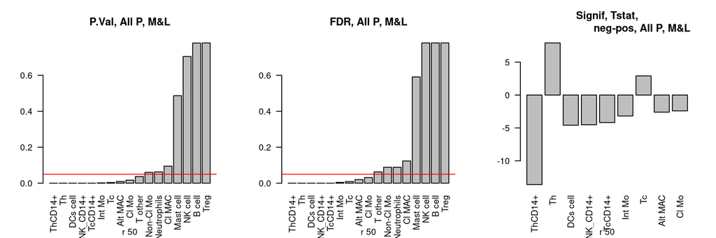

```r
> for_test_LM <- for_test[for_test$CellType_h2 %in% c("Lymphoid cell", "Myeloid cell"),]
> ttl <- "All P, M&L"
> res <- test_with_propeller(for_test_LM, "updCellType",ttl)
```

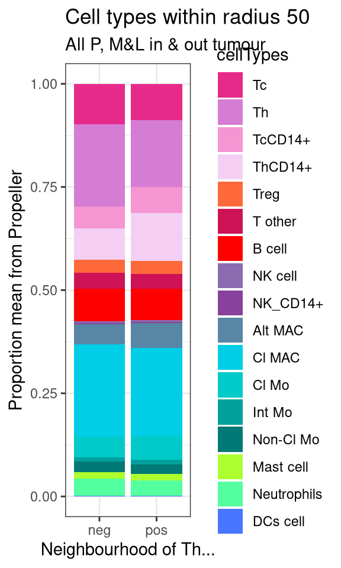

```r
> plot_prop(res, paste(ttl, status))
```

### 3.4.2 L immune subgroup

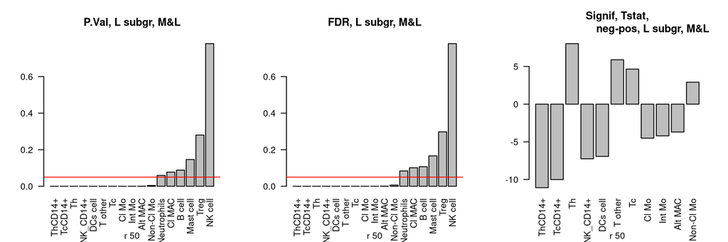

```r
> for_test_LM <- for_test_LM[for_test_LM$immuneSubgroups == "L",]
> ttl <- "L subgr, M&L"
> res <- test_L_imm_subgr_with_propeller(for_test_LM, "updCellType",ttl)
```

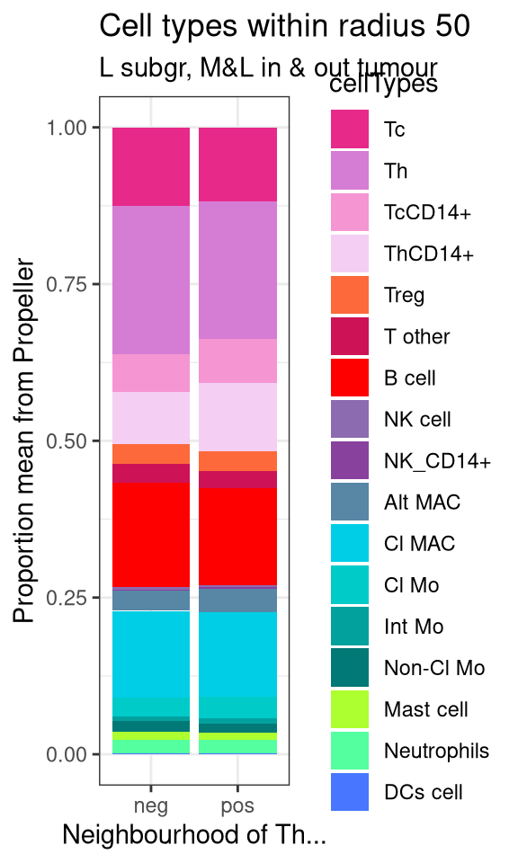

```r
> plot_prop(res, paste(ttl, status))
```

```r
> png("../plots/Tstatistics_from_propeller_nbhd_proportions_test.png")
> plot_col_test_res(res, paste(ttl, status), cd14pos_L_and_M_colors)
> dev.off()
```